# High dose versus low dose oral steroids for infantile spasms

We evaluate here whether low dose of oral steroids are associated with low effectiveness controlling infantile spasms.

## Install needed package

```r
# install.packages("meta")
library (meta)
```

```
## Loading 'meta' package (version 4.9-7).
## Type 'help(meta)' for a brief overview.
```

## Prednisolone and prednisone

#### Prednisolone and prednisone data

Data from the studies on the effectiveness of prednisolone and prednisone for infantile spasms.

```r
# Prednisolone data
PRD <- metaprop(
  event = c( 5,  4, 21, 13, 7,  8, 16, 28, 16, 30, 62, 60,  28,  5),
  n = c(    12, 14, 30, 17, 7, 32, 31, 48, 20, 54, 87, 102, 39, 15),
  studlab = c(
              "Hrachovy et al, 1983 [low dose]",
              "Baram et al, 1996 [low dose]",
              "Lux et al, 2004",
              "Ware et al, 2012",
              "Adhami & Harini, 2013",
              "Chellamuthu et al, 2014 [low dose]",
              "Chellamuthu et al, 2014 [high dose]",
              "Wanigasinghe et al, 2015",
              "Yi et al, 2015",
              "Knupp et al, 2016",
              "Gonzalez-Giraldo et al, 2018",
              "Eliyan et al, 2019",
              "Yi et al, 2019",
              "Gowda et al, 2019"
  ),
  method="Inverse"
               )
```

##### Prednisolone and prednisone forest plot

Forest plot summarizing the data on effectiveness for prednisolone and prednisone for infantile spasms (probability of resolving infantile spasms 2 weeks after treatment initiation).

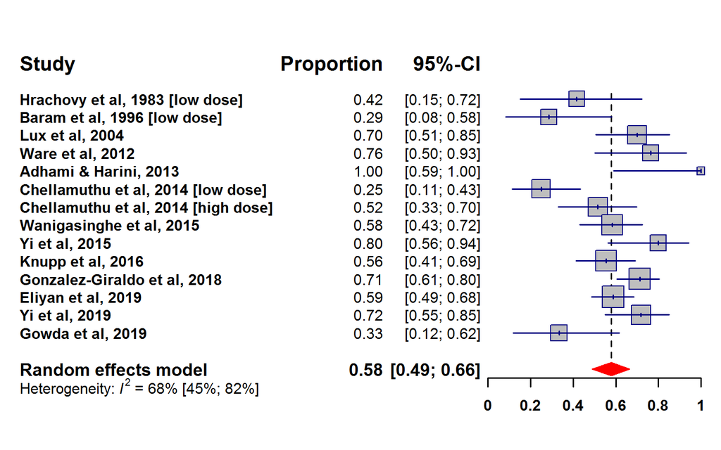

```r
# Forest plot
forest(PRD, comb.fixed = FALSE, lty.random=2, lty.fixed = 0,
       xlim = c(0, 1), lwd = 1.75, col.study = "navy", col.square = "gray", col.square.lines = "navy",
       col.diamond.random = "red", col.diamond.lines.random = "red",
       print.I2 = TRUE, print.I2.ci = TRUE, print.tau2 = FALSE, print.pval.Q = FALSE,
       fontsize = 12, fs.heading = 16, fs.hetstat = 12, fs.axis = 12, fs.test.overall = 12,
       fs.random = 14, fs.smlab = 14, ff.study.labels =  "bold",
       ff.axis = "bold", squaresize = 1.2,
       backtransf = TRUE, test.overall.random = TRUE,
       leftcols = c("studlab", "effect", "ci"), rightcols = FALSE,
       just = "right", digits = 2)
```

The forest plot for this random-effects meta-analysis shows that the estimated effectiveness (resolving infantile spasms at 2 weeks after treatment) of oral steroids (prednisolone and prednisone) is 58%, with a 95% confidence interval between 49% and 66%.

It also shows that there is significant between-study heterogeneity with an $I^2$ of 68% (95% confidence interval: 45% to 82%).

Most of the studies with the lowest estimated effectiveness were studies using low-dose prednisone or low-dose prednisolone: Hrachovy et al, 1983 used oral prednisone 2 mg/Kg/day, Baram et al, 1996 used oral prednisone 2 mg/Kg/day, and the low-dose arm of Chellamuthu et al, 2014 used oral prednisolone 2 mg/Kg/day.

Therefore, we evaluated whether there was a different effectiveness among patients using low-dose and high-dose oral steroids.

#### Prednisolone and prednisone by subgroups (low-dose versus high-dose) data

Data from the studies on the effectiveness of low-dose versus high-dose oral steroids for infantile spasms.

```r
# Metaanalysis considering subgroups by AED
PRD_subgroups <- metaprop(event = c(5,  4,  8,                                                ### LOW DOSE
                                    21, 13, 7, 16, 28, 16, 30, 62, 60,  28,  5),              ### HIGH DOSE

               n = c(              12, 14,  32,                                               ### LOW DOSE
                                   30, 17,  7, 31, 48, 20, 54, 87, 102, 39, 15),              ### HIGH DOSE

               c("Hrachovy et al, 1983 [low dose]",
                 "Baram et al, 1996 [low dose]",
                 "Chellamuthu et al, 2014 [low dose]",                                        ### LOW DOSE

                 "Lux et al, 2004",
                 "Ware et al, 2012",
                 "Adhami & Harini, 2013",
                 "Chellamuthu et al, 2014 [high dose]",
                 "Wanigasinghe et al, 2015",
                 "Yi et al, 2015",
                 "Knupp et al, 2016",
                 "Gonzalez-Giraldo et al, 2018",
                 "Eliyan et al, 2019",
                 "Yi et al, 2019",
                 "Gowda et al, 2019"),                                                        ### HIGH DOSE


               byvar = c("Low dose", "Low dose", "Low dose",                                  ### LOW DOSE

                         "High dose", "High dose", "High dose", "High dose", "High dose",
                         "High dose", "High dose", "High dose", "High dose", "High dose",
                         "High dose"),                                                        ### HIGH DOSE
  method="Inverse"
               )
```

#### Prednisolone and prednisone by subgroups (low-dose versus high-dose) forest plot

Forest plot summarizing the data on effectiveness (probability of resolving infantile spasms 2 weeks after treatment initiation) for low-dose versus high-dose oral steroids.

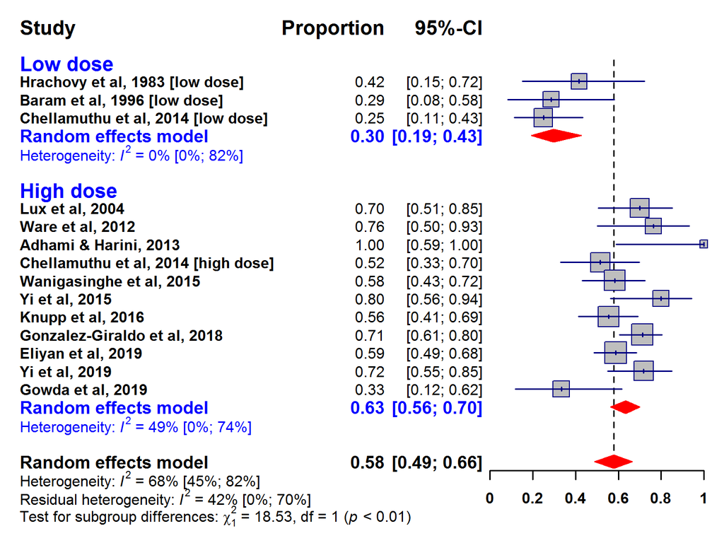

```r
forest(PRD_subgroups, comb.fixed = FALSE, lty.random=2, lty.fixed = 0,
       xlim = c(0, 1), lwd = 1.75, col.study = "navy", col.square = "gray", col.square.lines = "navy",
       col.diamond.random = "red", col.diamond.lines.random = "red",
       print.I2 = TRUE, print.I2.ci = TRUE, print.tau2 = FALSE, print.pval.Q = FALSE,
       fontsize = 12, fs.heading = 16, fs.hetstat = 12, fs.axis = 12, fs.test.overall = 12,
       fs.random = 14, fs.smlab = 14, ff.study.labels =  "bold",
       ff.axis = "bold", squaresize = 1.2,
       backtransf = TRUE, test.overall.random = TRUE,
       leftcols = c("studlab", "effect", "ci"), rightcols = FALSE,
       just = "right", digits = 2, bylab = "DOSE",
       print.byvar = FALSE, col.by = "blue", overall = TRUE, overall.hetstat = TRUE,
       test.subgroup.random = TRUE, fs.test.subgroup.random = 15)
```

This forest plot shows that the overall estimation of effectiveness of prednisone and prednisolone: 58% (95% confidence interval: 49% to 66%) is a composite of two very different estimates:

-The effectiveness of low-dose prednisone or prednisolone: 30% (95% confidence interval: 19% to 43%).

-The effectiveness of high-dose prednisone or prednisolone: 63% (95% confidence interval: 56% to 70%).

The difference in effectiveness between the low-dose and high-dose subgroups is statistically significant with a p-value < 0.01.

The difference between these subgroups also explains a large part of the between-study heterogeneity. The global $I^2$ is 68% (95% confidence interval: 45% to 82%), but the $I^2$ for the low-dose group is 0% (95% confidence interval: 0% to 82%) and the $I^2$ for the high-dose group is 49% (95% confidence interval: 0% to 74%).

## Oral steroids data evaluating subgroups for potential publication bias

#### Low-dose oral steroids evaluation for potential publication bias

Data from the studies on the effectiveness of low dose oral steroids for infantile spasms.

```r
# Low dose oral steroids data
Lowdose_PRD <- metaprop(
  event = c( 5,  4,  8),
  n = c(    12, 14, 32),
  studlab = c(
              "Hrachovy et al, 1983 [low dose]",
              "Baram et al, 1996 [low dose]",
              "Chellamuthu et al, 2014 [low dose]"
  ),
  method="Inverse"
               )
```

Forest plot summarizing the data on effectiveness for low dose oral steroids for infantile spasms

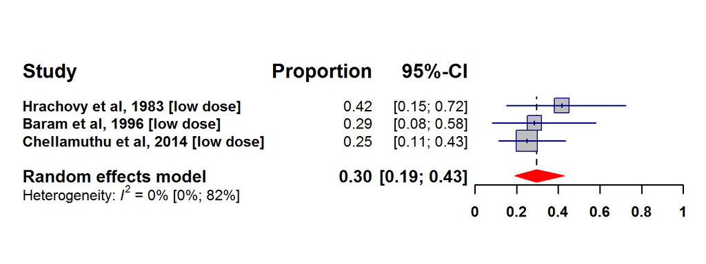

```r
# Forest plot
forest(Lowdose_PRD, comb.fixed = FALSE, lty.random=2, lty.fixed = 0,
       xlim = c(0, 1), lwd = 1.75, col.study = "navy", col.square = "gray", col.square.lines = "navy",
       col.diamond.random = "red", col.diamond.lines.random = "red",
       print.I2 = TRUE, print.I2.ci = TRUE, print.tau2 = FALSE, print.pval.Q = FALSE,
       fontsize = 12, fs.heading = 16, fs.hetstat = 12, fs.axis = 12, fs.test.overall = 12,
       fs.random = 14, fs.smlab = 14, ff.study.labels =  "bold",
       ff.axis = "bold", squaresize = 1.2,
       backtransf = TRUE, test.overall.random = TRUE,
       leftcols = c("studlab", "effect", "ci"), rightcols = FALSE,
       just = "right", digits = 2)
```

Small studies tend to have more extreme results (either more positive or more negative results) just because a smaller sample size leads to more variability in the estimate than a larger sample size.

However, positive results tend to be published more often than negative results, leading to publication bias.

We evaluate publication bias visually through a funnel plot.

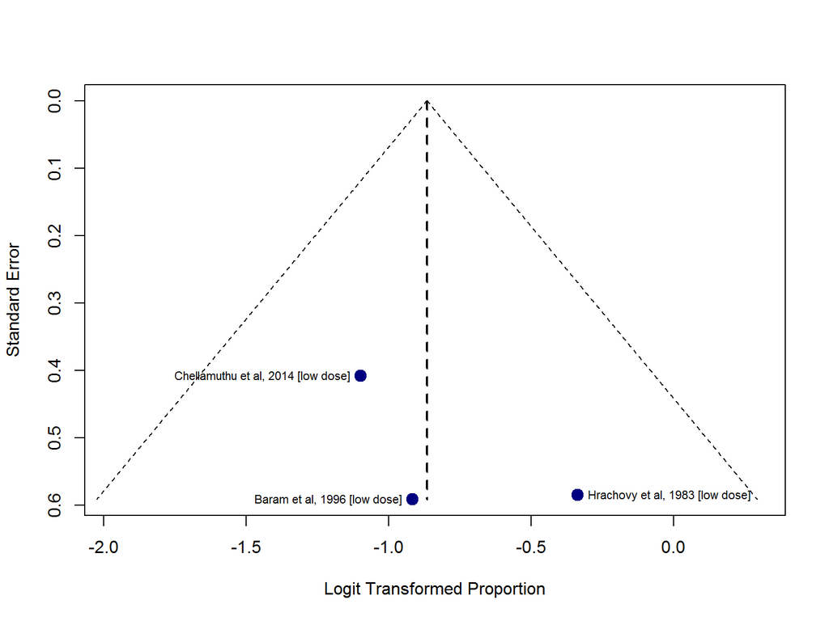

```r
# Funnel plot names
funnel(Lowdose_PRD, comb.fixed = FALSE, comb.random = TRUE, pch = 21, cex = 1.5,
       lty.random = 2, lwd.random = 2, bg = "navy", col = "navy",
       studlab = TRUE, cex.studlab = 0.7, pos.studlab = c(4, 2, 2))
```

This funnel plot shows that small studies (low on the y-axis) tend to have estimates of the effectiveness of oral steroids higher (right on the x-axis) than larger studies suggesting some degree of publication bias leading to some degree of overestimation of the effectiveness of oral steroids. However, with only three studies, two of them with small sample size, it is difficult to estimate publication bias.

The trim and fill method artificially compensates for the studies that are probably causing publication bias (small studies that are distributed asymmetrically) artificially creating small studies symmetrically distributed from the existing small studies (studies which probably existed but probably were not published).

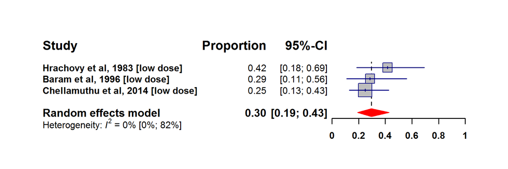

```r
# Low dose oral steroids data trimandfill
Lowdose_PRD_trimandfill <- trimfill(Lowdose_PRD, ma.fixed = TRUE, comb.random = TRUE)

# Forest plot
forest(Lowdose_PRD_trimandfill, comb.fixed = FALSE, lty.random=2, lty.fixed = 0,
       xlim=c(0, 1), lwd = 1.75, col.study = "navy", col.square = "gray", col.square.lines = "navy",
       col.diamond.random = "red", col.diamond.lines.random = "red",
       print.I2 = TRUE, print.I2.ci = TRUE, print.tau2 = FALSE, print.pval.Q = FALSE,
       fontsize = 12, fs.heading = 16, fs.hetstat = 12, fs.axis = 12, fs.test.overall = 12,
       fs.random = 14, fs.smlab = 14, ff.study.labels =  "bold",
       ff.axis = "bold", squaresize = 1.2,
       backtransf = TRUE, test.overall.random = FALSE,
       leftcols = c("studlab", "effect", "ci"), rightcols = FALSE,
       just = "right", digits = 2, print.zval = FALSE, label.test.overall.random = FALSE)
```

The forest plot imputing studies that “adjust” for potential publication bias show that, potentially, without publication bias, the pooled estimate of effectiveness of low dose oral steroids would be the same.

This could be because there is limited publication bias or because only trhee studies, it is difficult to estimate and adjust for publication bias.

We evaluate publication bias visually through a funnel plot.

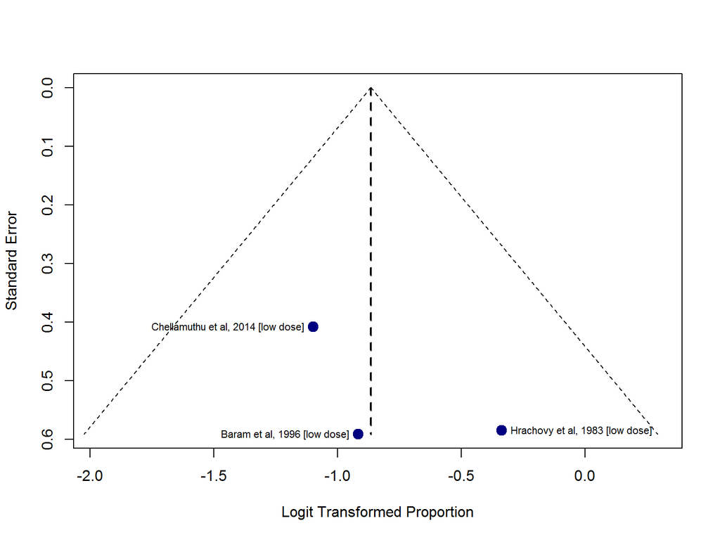

```r
# Funnel plot
funnel(Lowdose_PRD_trimandfill, comb.fixed = FALSE, comb.random = TRUE, pch = 21, cex = 1.5,
       lty.random = 2, lwd.random = 2,
       bg = c("navy", "navy", "navy"),
       col = c("navy", "navy", "navy"),
       studlab = TRUE, cex.studlab = 0.7, pos.studlab = c(4, 2, 2))
```

Obviously, the funnel plot is the same because no studies were imputted.

#### High dose oral steroids evaluation for potential publication bias

Data from the studies on the effectiveness of high dose oral steroids for infantile spasms.

```r
# High dose oral steroids data
Highdose_PRD <- metaprop(
  event = c( 21, 13, 7, 16, 28, 16, 30, 62, 60,  28,  5),
  n = c(     30, 17, 7, 31, 48, 20, 54, 87, 102, 39, 15),
  studlab = c(
              "Lux et al, 2004",
              "Ware et al, 2012",
              "Adhami & Harini, 2013",
              "Chellamuthu et al, 2014 [high dose]",
              "Wanigasinghe et al, 2015",
              "Yi et al, 2015",
              "Knupp et al, 2016",
              "Gonzalez-Giraldo et al, 2018",
              "Eliyan et al, 2019",
              "Yi et al, 2019",
              "Gowda et al, 2019"
  ),
  method="Inverse"
               )
```

Forest plot summarizing the data on effectiveness for high dose oral steroids for infantile spasms

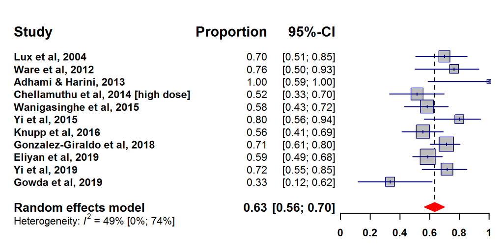

```r
# Forest plot
forest(Highdose_PRD, comb.fixed = FALSE, lty.random=2, lty.fixed = 0,
       xlim = c(0, 1), lwd = 1.75, col.study = "navy", col.square = "gray", col.square.lines = "navy",
       col.diamond.random = "red", col.diamond.lines.random = "red",
       print.I2 = TRUE, print.I2.ci = TRUE, print.tau2 = FALSE, print.pval.Q = FALSE,
       fontsize = 12, fs.heading = 16, fs.hetstat = 12, fs.axis = 12, fs.test.overall = 12,
       fs.random = 14, fs.smlab = 14, ff.study.labels =  "bold",
       ff.axis = "bold", squaresize = 1.2,
       backtransf = TRUE, test.overall.random = TRUE,
       leftcols = c("studlab", "effect", "ci"), rightcols = FALSE,
       just = "right", digits = 2)
```

Small studies tend to have more extreme results (either more positive or more negative results) just because a smaller sample size leads to more variability in the estimate than a larger sample size.

However, positive results tend to be published more often than negative results, leading to publication bias.

We evaluate publication bias visually through a funnel plot.

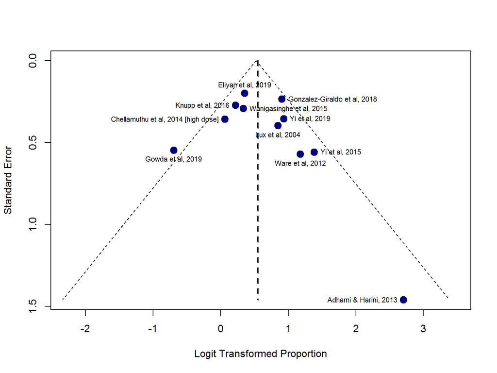

```r
# Funnel plot names
funnel(Highdose_PRD, comb.fixed = FALSE, comb.random = TRUE, pch = 21, cex = 1.5,
       lty.random = 2, lwd.random = 2, bg = "navy", col = "navy",
       studlab = TRUE, cex.studlab = 0.7, pos.studlab = c(1, 1, 2, 2, 4, 4, 2, 4, 3, 4, 1))
```

This funnel plot shows that small studies (low on the y-axis) tend to have estimates of the effectiveness of oral steroids higher (right on the x-axis) than larger studies suggesting some degree of publication bias leading to some degree of overestimation of the effectiveness of oral steroids.

The trim and fill method artificially compensates for the studies that are probably causing publication bias (small studies that are distributed asymmetrically) artificially creating small studies symmetrically distributed from the existing small studies (studies which probably existed but probably were not published).

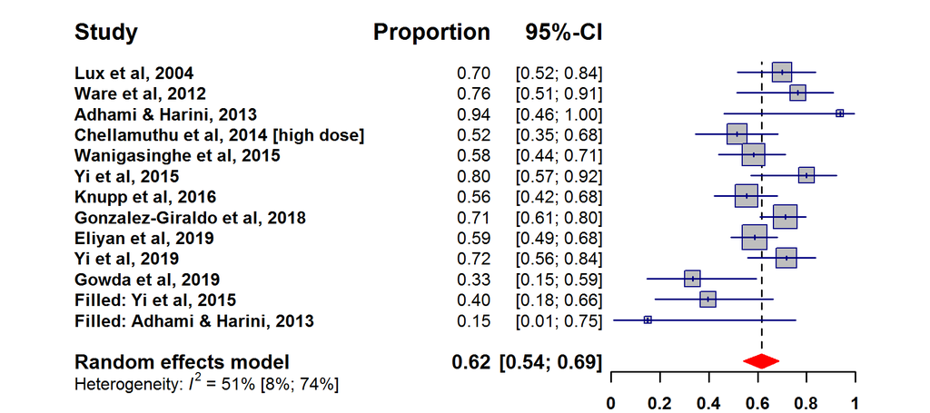

```r
# High dose oral steroids data trimandfill
Highdose_PRD_trimandfill <- trimfill(Highdose_PRD, ma.fixed = TRUE, comb.random = TRUE)

# Forest plot
forest(Highdose_PRD_trimandfill, comb.fixed = FALSE, lty.random=2, lty.fixed = 0,
       xlim=c(0, 1), lwd = 1.75, col.study = "navy", col.square = "gray", col.square.lines = "navy",
       col.diamond.random = "red", col.diamond.lines.random = "red",
       print.I2 = TRUE, print.I2.ci = TRUE, print.tau2 = FALSE, print.pval.Q = FALSE,
       fontsize = 12, fs.heading = 16, fs.hetstat = 12, fs.axis = 12, fs.test.overall = 12,
       fs.random = 14, fs.smlab = 14, ff.study.labels =  "bold",
       ff.axis = "bold", squaresize = 1.2,
       backtransf = TRUE, test.overall.random = FALSE,
       leftcols = c("studlab", "effect", "ci"), rightcols = FALSE,
       just = "right", digits = 2, print.zval = FALSE, label.test.overall.random = FALSE)
```

The forest plot imputing studies that “adjust” for potential publication bias show that, potentially, without publication bias, the pooled estimate of effectiveness of high dose oral steroids would be approximately 62% with a 95% confidence interval from 54% to 69%.

That is lower than the unadjusted estimate of 63%, with a 95% confidence interval from 56% to 70%. This suggests that the effectiveness of high dose oral steroids around 63% is probably not markedly modified by publication bias.

We evaluate publication bias visually through a funnel plot.

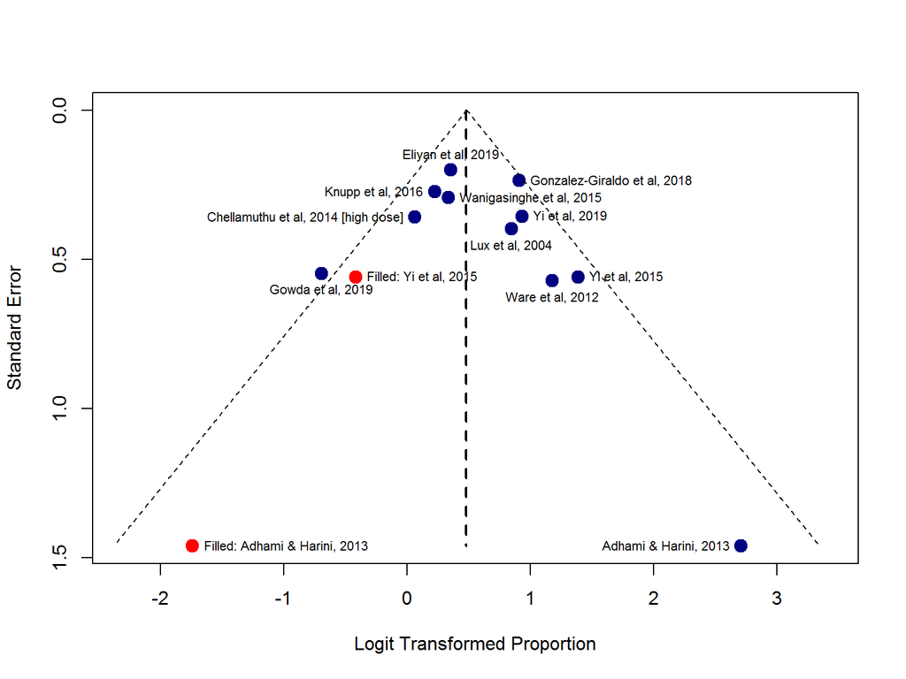

```r
# Funnel plot
funnel(Highdose_PRD_trimandfill, comb.fixed = FALSE, comb.random = TRUE, pch = 21, cex = 1.5,
       lty.random = 2, lwd.random = 2,
       bg = c("navy", "navy", "navy", "navy", "navy", "navy", "navy", "navy", "navy", "navy", "navy", "red", "red"),
       col = c("navy", "navy", "navy", "navy", "navy", "navy", "navy", "navy", "navy", "navy", "navy", "red", "red"),
       studlab = TRUE, cex.studlab = 0.7, pos.studlab = c(1, 1, 2, 2, 4, 4, 2, 4, 3, 4, 1, 4, 4))
```

Obviously, “adjusting” for potential publication bias shows a more balanced plot. In red, the inputted studies to compensate for potential publication bias.

#### Comparison of low dose versus high dose oral steroids evaluating for potential publication bias

Data from the studies on the effectiveness of low dose and high dose oral steroids for infantile spasms adjusting for potential publication bias.

```r
# Meta-analysis considering subgroups by groups: low dose and high dose oral steroids
COMPARISON_lowvshighdose_PRD <- metagen(TE = c(Lowdose_PRD_trimandfill$TE,               ### LOW DOSE
                                               Highdose_PRD_trimandfill$TE),             ### HIGH DOSE

               seTE = c(              Lowdose_PRD_trimandfill$seTE,                      ### LOW DOSE
                                      Highdose_PRD_trimandfill$seTE),                    ### HIGH DOSE

               studlab = c(Lowdose_PRD_trimandfill$studlab,                              ### LOW DOSE
                           Highdose_PRD_trimandfill$studlab),                            ### HIGH DOSE


               byvar = c(
                         rep("Low dose", length(Lowdose_PRD_trimandfill$studlab)),       ### LOW DOSE
                         rep("High dose", length(Highdose_PRD_trimandfill$studlab))      ### HIGH DOSE
),
  sm = "PLOGIT"
               )
```

Forest plot comparison low dose versus high dose oral steroids adjusting for publication bias

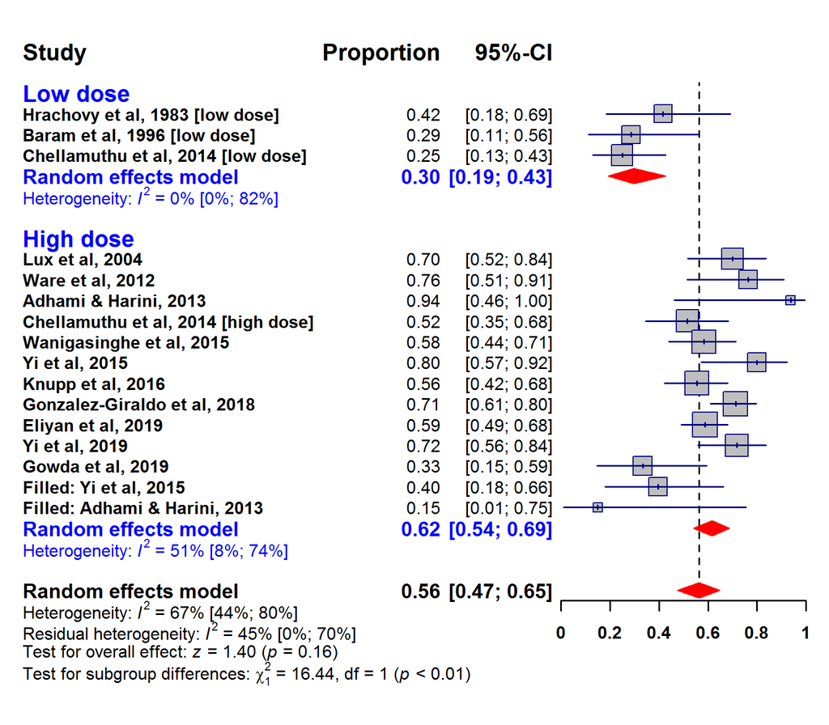

```r
forest(COMPARISON_lowvshighdose_PRD, comb.fixed = FALSE, lty.random=2, lty.fixed = 0,
       xlim = c(0, 1), lwd = 1.75, col.study = "navy", col.square = "gray", col.square.lines = "navy",
       col.diamond.random = "red", col.diamond.lines.random = "red",
       print.I2 = TRUE, print.I2.ci = TRUE, print.tau2 = FALSE, print.pval.Q = FALSE,
       fontsize = 12, fs.heading = 16, fs.hetstat = 12, fs.axis = 12, fs.test.overall = 12,
       fs.random = 14, fs.smlab = 14, ff.study.labels =  "bold",
       ff.axis = "bold", squaresize = 1.2,
       backtransf = TRUE, test.overall.random = TRUE,
       leftcols = c("studlab", "effect", "ci"), rightcols = FALSE,
       just = "right", digits = 2, bylab = "MEDICATION",
       print.byvar = FALSE, col.by = "blue", overall = TRUE, overall.hetstat = TRUE,
       test.subgroup.random = TRUE, fs.test.subgroup.random = 15)
```

This forest plot shows that the overall estimation of effectiveness of oral steroids after adjusting for potential publication bias is: 56% (95% confidence interval: 47% to 65%) is a composite of two very different estimates:

-The effectiveness of low dose oral steroids: 30% (95% confidence interval: 19% to 43%).

-The effectiveness of high dose oral steroids: 62% (95% confidence interval: 54% to 69%).

The difference in effectiveness between the low dose oral steroids and high dose oral steroids subgroups is statistically significant with a p-value < 0.01.

The difference between these subgroups also explains a large part of the between-study heterogeneity. The global $I^2$ is 67% (95% confidence interval: 44% to 80%), but the $I^2$ for the low-dose group is 0% (95% confidence interval: 0% to 82%) and the $I^2$ for the high-dose group is 51% (95% confidence interval: 8% to 74%).

#### We found (as Chellamuthu et al, 2014 found previously) that the effectiveness of prednisolone and prednisone may be much lower when given at low dose. Therefore, we will continue the rest of the analysis considering only the data for prednisone or prednisolone given at appropriate doses for infantile spasms.